# Fonts

Carole Voulgaris

9/11/2020

```r
library(tidyverse)
library(extrafont)
library(extrafontdb)
```

The default fonts in R might not be that interesting to you. Here is how you can get a little more flexibility.

Let’s start with a simple scatterplot.

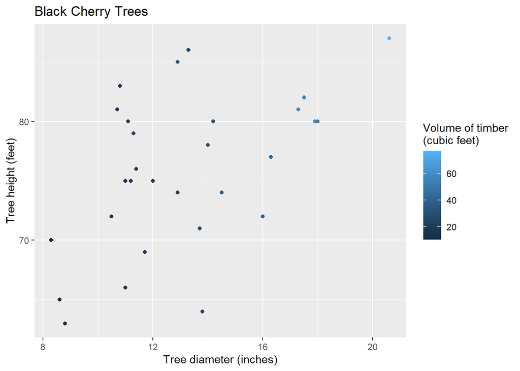

```r
example_plot <- ggplot(trees, aes(x = Girth,
                                  y = Height,
                                  color = Volume)) +
    geom_point() +
    ggtitle("Black Cherry Trees") +
    scale_x_continuous(name = "Tree diameter (inches)") +
    scale_y_continuous(name = "Tree height (feet)") +
    scale_color_continuous(name = "Volume of timber\n(cubic feet)")

example_plot
```

The default font is Arial or Helvetica, and it’s fine. But maybe you want more options.

To make all the fonts on your computer available to R, type `font_import()` into your console and press Enter. You only need to ever do this once. It takes some time to import all the fonts, so you’ll get a prompt to type y or n (yes or no) to confirm that you really want to do that. Type `y` and press Enter.

Now you can see a list of all the fonts that are available to you. Here’s what I have on my computer (it’s a PC).

```r
fonts()
```

```
##   [1] "Agency FB"                       "Algerian"
##   [3] "Arial Black"                     "Arial"
##   [5] "Arial Narrow"                    "Arial Rounded MT Bold"
##   [7] "Bahnschrift"                     "Baskerville Old Face"
##   [9] "Bauhaus 93"                      "Bell MT"
##  [11] "Berlin Sans FB"                  "Berlin Sans FB Demi"
##  [13] "Bernard MT Condensed"            "Blackadder ITC"
##  [15] "Bodoni MT"                       "Bodoni MT Black"
##  [17] "Bodoni MT Condensed"             "Bodoni MT Poster Compressed"
##  [19] "Book Antiqua"                    "Bookman Old Style"
##  [21] "Bookshelf Symbol 7"              "Bradley Hand ITC"
##  [23] "Britannic Bold"                  "Broadway"
##  [25] "Brush Script MT"                 "Calibri"
##  [27] "Calibri Light"                   "Californian FB"
##  [29] "Calisto MT"                      "Cambria"
```

[output cut: 113 more lines]

Now I need to load these fonts using the function `loadfonts()`. If you are working on a Mac, you can leave leave the parentheses empty (i.e. delete `device = "win"`)

```r
loadfonts(device = "win")
```

To use one of these fonts in your plot, use the `theme()` function.

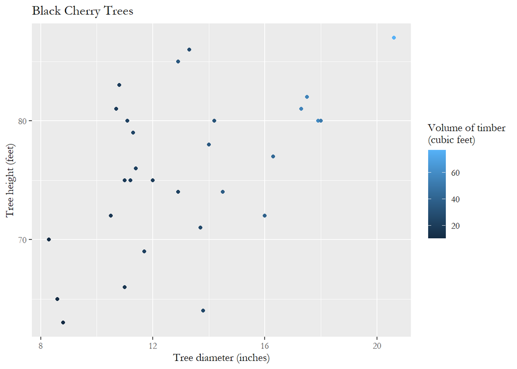

```r
example_plot +
  theme(text = element_text(family = "Garamond"))
```

Maybe you want to use different fonts for different text elements. No problem.

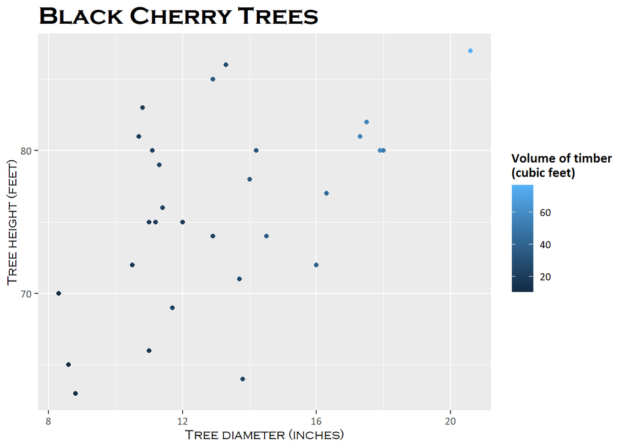

```r
example_plot +
  theme(plot.title = element_text(family = "Copperplate Gothic Bold",
                             size = 20),
        axis.title = element_text(family = "Copperplate Gothic Light"),
        axis.text = element_text(family = "Calibri" ),
        legend.title = element_text(family = "Calibri", face = "bold"),
        legend.text = element_text(family = "Calibri" ))
```